# BCB420 Assignment 1

Dataset Selection and Initial Processing

Maryam Hasanzadehkiabi

2023-02-21

# 1. Dataset selection

## Insert and running required packages

```r
if (!requireNamespace("rmarkdown", quietly = TRUE))
    +     install.packages("rmarkdown")
if (!requireNamespace("knitr", quietly = TRUE))
    +     install.packages("knitr")
#if (!requireNamespace("pandoc", quietly = TRUE))
#    +     install.packages("pandoc")
if (!requireNamespace("devtools", quietly = TRUE))
    +     install.packages("devtools")
if (!requireNamespace("BiocManager", quietly = TRUE))
    +     install.packages("BiocManager")
if (!requireNamespace("edgeR", quietly = TRUE))
    BiocManager::install("edgeR")
if (!requireNamespace("biomaRt", quietly = TRUE))
    BiocManager::install("biomaRt")
if (!requireNamespace("GEOmetadb", quietly = TRUE))
    BiocManager::install("GEOmetadb")
if (!requireNamespace("GEOquery", quietly = TRUE))
    +     install.packages("GEOquery")
if (!requireNamespace("DBI", quietly = TRUE))
    +     install.packages("DBI")
if (!requireNamespace("RSQLite", quietly = TRUE))
    +     install.packages("RSQLite")
if(!requireNamespace("kableExtra", quietly=TRUE))
    install.packages("kableExtra")
```

```r
library(devtools)
library(rmarkdown)
library(knitr)
library(pandoc)
library(BiocManager)
library(GEOmetadb)
library(GEOquery)
library(DBI)
library(RSQLite)
library(edgeR)
library(biomaRt)
library(kableExtra)
```

## Dataset Selection Criteria

1. RNASeq data
2. Within the last 10 years
3. Limited to human
4. Number of samples more than 6
5. Related to Metabolic Syndrome

```r
sql <- paste("SELECT DISTINCT gse.title,gse.gse, gpl.title,",
             " gse.submission_date,",
             " gse.supplementary_file",
             "FROM",
             "  gse JOIN gse_gpl ON gse_gpl.gse=gse.gse",
             "  JOIN gpl ON gse_gpl.gpl=gpl.gpl",
             "WHERE",
             "  gse.submission_date > '2013-01-01' AND",
             "  gse.title LIKE '%Metabolic Syndrome%' AND",
             "  gpl.organism LIKE '%Homo sapiens%' AND",
             "  gpl.technology LIKE '%high-throughput sequencing%' ",
             "  ORDER BY gse.submission_date DESC",sep=" ")
```

Selecting series with counts data

## Details of the Selected Series

Name and number of the samples

Series include 10 samples.

Samples classification

There are 2 groups, 5 healthy/control individuals and 5 patients with metabolic syndrome.

# 2. Data expression

Supplementary files

```r
supp_files = getGEOSuppFiles('GSE166474')
file_names = rownames(supp_files)
print(file_names)
```

```
## [1] "/home/rstudio/projects/Desktop/BCB420/Maryam_Hasanzadehkiabi/GSE166474/GSE166474_KRM_RawCounts.txt.gz"
## [2] "/home/rstudio/projects/Desktop/BCB420/Maryam_Hasanzadehkiabi/GSE166474/GSE166474_KRM_TPMnormalized.txt.gz"
```

There are two supplementary files provided for this dataset, one includes raw counts and the other one contains TPM normalized data.<sup>20</sup> Raw counts file is being used for further analysis. Researchers studied lncRNA, miRNA and mRNA differential expression of extracellular vesicles (EVs), and the effect of metabolic syndrome on their interactions<sup>20</sup>

Displaying first 10 genes expression on 3 samples

```r
genes_expression = read.delim(file_names[1],header=TRUE,
          check.names = FALSE)
genes_expression[1:10, 1:4] %>%
    kableExtra::kbl(caption = "Genes Expression in 3 samples") %>%
    kableExtra::kable_classic(full_width = F, html_font = "Cambria")
```

Genes Expression in 3 samples

|  | M1_GTTCGCTCTC_60 | M2_GTTCTACGTT_61 | M3_GTTGAGATTC_62 |
| --- | --- | --- | --- |
| *ERCC-00033* | 0 | 0 | 0 |
| ENSG00000000003 | 0 | 0 | 0 |
| ENSG00000000005 | 0 | 0 | 0 |
| ENSG00000000419 | 1 | 0 | 0 |
| ENSG00000000457 | 0 | 0 | 0 |
| ENSG00000000460 | 0 | 1 | 4 |
| ENSG00000000938 | 3 | 0 | 4 |
| ENSG00000000971 | 0 | 0 | 0 |
| ENSG00000001036 | 0 | 0 | 0 |
| ENSG00000001084 | 1 | 1 | 3 |

In the following section, number of the genes and name of the variables included in the dataset are presented; since the first column includes gene IDs without column name, “ensembl_id” is assigned to the first column name.

```r
dim(genes_expression)
```

```
## [1] 32392    11
```

```r
colnames(genes_expression)[1] <- "ensembl_id"
colnames(genes_expression)
```

```
##  [1] "ensembl_id"       "M1_GTTCGCTCTC_60" "M2_GTTCTACGTT_61" "M3_GTTGAGATTC_62"
##  [5] "M4_TAACAGGCCG_63" "M6_TAATCTAGGC_65" "N3_TACCGTTCTT_66" "N4_TACGAGCTGC_67"
##  [9] "N5_TACGCTGCAG_68" "N6_TACGGCAACG_69" "N2_GATACTATGG_32"
```

Samples category

There are 2 groups included in the study, “M” indicates metabolic syndrome patients and “N” indicates healthy (normal) individuals. Each group contains 5 samples.

```r
dataSamples <- data.frame(lapply(colnames(genes_expression)[2:11],
            FUN = function(x){unlist(strsplit(x,
                              split = "\\_"))[c(1)]}))
colnames(dataSamples) <- colnames(genes_expression)[2:11]
rownames(dataSamples) <- c("Status")
dataSamples <- data.frame(t(dataSamples))
```

# 3. Genes cleaning and filtering

## Gene name structure

Removing genes that do not follow ensembl nomenclature

```r
validGenes <- genes_expression[grep("ENSG", genes_expression$ensembl_id),]
```

## Duplication

Checking potential duplication. If the logical output returns any “TRUE” value, there does exist duplication. Otherwise the set contains unique genes.

```r
summary(duplicated(validGenes$ensembl_id))
```

```
##    Mode   FALSE
## logical   32391
```

Since there is no “TRUE” value in the output, dataset includes only unique genes.

## Outliers

```r
cpms = cpm(validGenes[,2:11])
rownames(cpms) <- validGenes$ensembl_id
keep = rowSums(cpms > 2) >=5
genes_filtered = validGenes[keep,]
filtered_results <- data.frame(genes_expression = nrow(genes_expression), validGenes = nrow(validGenes), genes_filtered = nrow(genes_filtered))
rownames(filtered_results)[1] <- "Number of Genes"
filtered_results %>%
  kableExtra::kbl(caption = "Genes count") %>%
  kableExtra::kable_classic(full_width = F, html_font = "Cambria")
```

Genes count

|  | genes_expression | validGenes | genes_filtered |
| --- | --- | --- | --- |
| Number of Genes | 32392 | 32391 | 6903 |

In this dataset, there is 1 gene that does not follow the standard ensembl nomenclature, and there are 25,488 genes with low counts.

## Data distribution before normalization

Boxplot

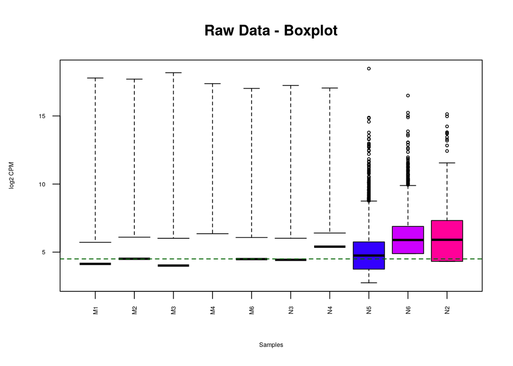

```r
data2plot <- log2(cpm(genes_filtered[,2:11]))
colnames(data2plot) <- lapply(colnames(genes_filtered)[2:11],
                              FUN=function(x) {unlist(strsplit(x,
                              split="\\_"))[c(1)]})
boxplot(data2plot, xlab = "Samples", ylab = "log2 CPM",
las = 2, cex = 0.5, cex.lab = 0.5,
cex.axis = 0.5, main = "Raw Data - Boxplot", col=rainbow(10))
abline(h = median(apply(data2plot, 2, median)),
col = "darkgreen", lwd = 1.2, lty = "dashed")
```

There are 3 outliers as negative infinity that are removed from plot. It seems that samples are very different.

Density plot

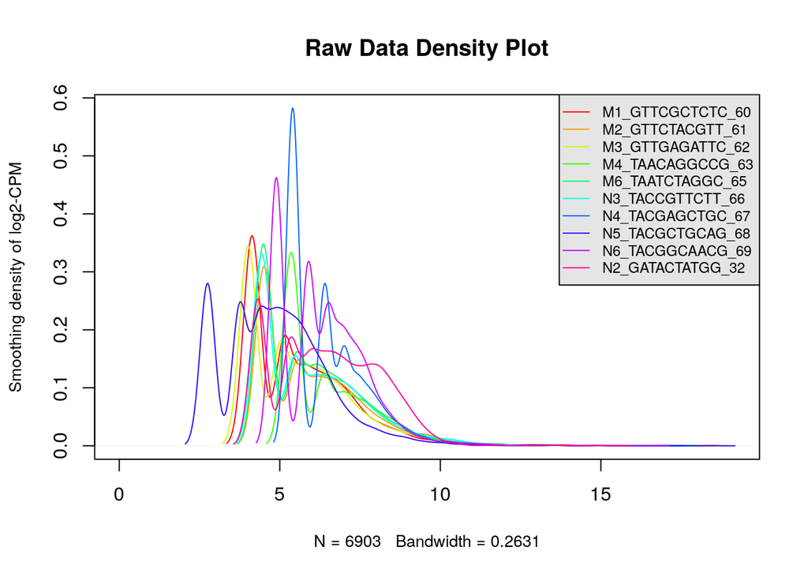

```r
counts_density <- apply(log2(cpm(genes_filtered[,2:11])),
2, density)
xlim <- 0; ylim <- 0
for (i in 1:length(counts_density)) {
xlim <- range(c(xlim, counts_density[[i]]$x));
ylim <- range(c(ylim, counts_density[[i]]$y))
}
cols <- rainbow(length(counts_density))
ltys <- rep(1, length(counts_density))
plot(counts_density[[1]], xlim=xlim, ylim=ylim, type="n",
ylab="Smoothing density of log2-CPM",
main="Raw Data Density Plot", cex.lab = 0.85)
for (i in 1:length(counts_density))
lines(counts_density[[i]], col=cols[i], lty=ltys[i])
legend("topright", colnames(genes_expression[2:11]),
col=cols, lty=ltys, cex=0.75,
border ="blue", text.col = "black",
merge = TRUE, bg = "gray90")
```

It seems that data follows a bimodal distribution pattern.

MA plot

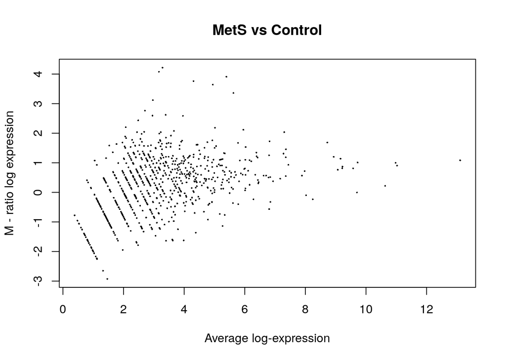

```r
plotMA(log2(genes_filtered[,c(2:6,7:11)]), ylab="M - ratio log expression",
main="MetS vs Control")
```

Scatter plot also does not show clustering around mean; there might be many outliers.

# 4. Mapping

To perform mapping, ensembl_gene_id is selected

```r
ensembl <- useMart("ensembl")
ensembl = useDataset("hsapiens_gene_ensembl",mart=ensembl)
gene_mapped <- getBM(attributes = c("ensembl_gene_id","hgnc_symbol"),
filters = c("ensembl_gene_id"),
values = genes_filtered$ensembl_id,
mart = ensembl)
```

```r
length(which(rownames(cpms) %in%
gene_mapped$ensembl_gene_id))
```

```
## [1] 6879
```

Total number of genes with measurements

```r
nrow(cpms)
```

```
## [1] 32391
```

Number of genes that could not be mapped

```r
nrow(cpms) - length(which(rownames(cpms) %in%
gene_mapped$ensembl_gene_id))
```

```
## [1] 25512
```

Merging raw data and mapped genes; presenting data in one metobolic syndrome patient and one healthy person

```r
cpms_annot <- merge(gene_mapped,cpms,
by.x = 1, by.y = 0, all.y=TRUE)
kable(cpms_annot[1:6,c(1,2,3,8)],format = "html")
```

| ensembl_gene_id | hgnc_symbol | M1_GTTCGCTCTC_60 | N3_TACCGTTCTT_66 |
| --- | --- | --- | --- |
| ENSG00000000003 | NA | 0.00000 | 0.00000 |
| ENSG00000000005 | NA | 0.00000 | 0.00000 |
| ENSG00000000419 | NA | 16.60330 | 0.00000 |
| ENSG00000000457 | NA | 0.00000 | 0.00000 |
| ENSG00000000460 | C1orf112 | 0.00000 | 20.16048 |
| ENSG00000000938 | FGR | 49.80989 | 0.00000 |

- Another method to check ensembl ID missing genes.

```r
length(ensembl_id_missing_gene <- cpms_annot$ensembl_gene_id[
which(is.na(cpms_annot$hgnc_symbol))])
```

```
## [1] 25512
```

Presenting the first 10 ensembl IDs that do not match with HUGO

```r
kable(cpms_annot[which(is.na(cpms_annot$hgnc_symbol)),1:3], format = "pipe")[3:12]
```

```
##  [1] "|1     |ENSG00000000003 |NA          |          0.00000|"
##  [2] "|2     |ENSG00000000005 |NA          |          0.00000|"
##  [3] "|3     |ENSG00000000419 |NA          |         16.60330|"
##  [4] "|4     |ENSG00000000457 |NA          |          0.00000|"
##  [5] "|7     |ENSG00000000971 |NA          |          0.00000|"
##  [6] "|8     |ENSG00000001036 |NA          |          0.00000|"
##  [7] "|10    |ENSG00000001167 |NA          |          0.00000|"
##  [8] "|11    |ENSG00000001460 |NA          |         16.60330|"
##  [9] "|12    |ENSG00000001461 |NA          |          0.00000|"
## [10] "|13    |ENSG00000001497 |NA          |          0.00000|"
```

Old mapping

```r
old_mapping <- merge(genes_expression,data.frame(ensembl_id_missing_gene), by.x = 1, by.y = 1)
kable(old_mapping[1:10,], type="pipe")
```

| ensembl_id | M1_GTTCGCTCTC_60 | M2_GTTCTACGTT_61 | M3_GTTGAGATTC_62 | M4_TAACAGGCCG_63 | M6_TAATCTAGGC_65 | N3_TACCGTTCTT_66 | N4_TACGAGCTGC_67 | N5_TACGCTGCAG_68 | N6_TACGGCAACG_69 | N2_GATACTATGG_32 |
| --- | --- | --- | --- | --- | --- | --- | --- | --- | --- | --- |
| ENSG00000000003 | 0 | 0 | 0 | 0 | 0 | 0 | 0 | 1 | 0 | 0 |
| ENSG00000000005 | 0 | 0 | 0 | 0 | 0 | 0 | 0 | 0 | 0 | 0 |
| ENSG00000000419 | 1 | 0 | 0 | 1 | 0 | 0 | 0 | 1 | 0 | 2 |
| ENSG00000000457 | 0 | 0 | 0 | 0 | 0 | 0 | 1 | 0 | 0 | 1 |
| ENSG00000000971 | 0 | 0 | 0 | 0 | 0 | 0 | 0 | 0 | 0 | 1 |
| ENSG00000001036 | 0 | 0 | 0 | 0 | 0 | 0 | 0 | 1 | 0 | 0 |
| ENSG00000001167 | 0 | 0 | 3 | 0 | 0 | 0 | 0 | 1 | 1 | 1 |
| ENSG00000001460 | 1 | 0 | 0 | 0 | 0 | 0 | 1 | 2 | 1 | 0 |
| ENSG00000001461 | 0 | 1 | 0 | 0 | 0 | 0 | 3 | 1 | 0 | 2 |
| ENSG00000001497 | 0 | 7 | 1 | 0 | 1 | 0 | 0 | 0 | 0 | 0 |

# 5. Normalization

Checking potential duplication

```r
summary(duplicated(gene_mapped$ensembl_gene_id))
```

```
##    Mode   FALSE    TRUE
## logical    6879       1
```

Removing duplication, and creating appropriate file to perform normalization analysis

```r
gene_mapped_unique <- unique(gene_mapped$ensembl_gene_id)
gene_mapped_unique <- data.frame(gene_mapped_unique)
rownames(gene_mapped_unique) <- gene_mapped_unique$gene_mapped_unique
gene_mapped_unique_counts = genes_expression[which(rownames(gene_mapped_unique)%in% genes_expression$ensembl_id),]
```

MA Plot

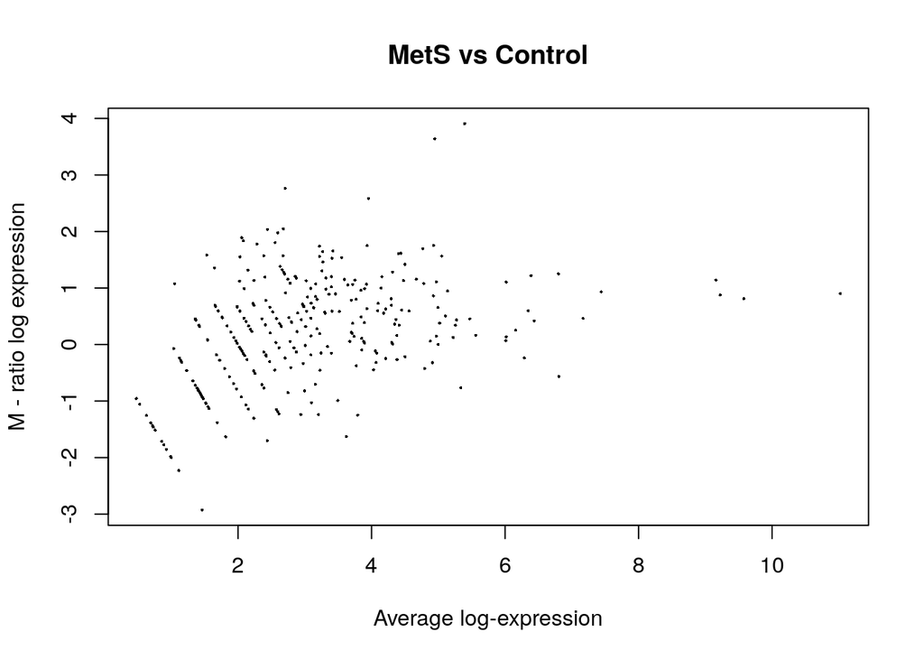

```r
plotMA(log2(gene_mapped_unique_counts[,c(2:6,7:11)]), ylab="M - ratio log expression",main="MetS vs Control")
```

Trimmed Mean of M-values (TMM)

```r
filtered_data_matrix <- as.matrix(gene_mapped_unique_counts[,2:11])
rownames(filtered_data_matrix) <- gene_mapped_unique_counts$ensembl_id
d = DGEList(counts=filtered_data_matrix, group = dataSamples$Status)
```

Normalization factors

```r
d = calcNormFactors(d)
kable(d$samples[,], format = "html") %>% row_spec(c(1,8,9,10), background = "yellow")
```

|  | group | lib.size | norm.factors |
| --- | --- | --- | --- |
| M1_GTTCGCTCTC_60 | M1 | 16423 | 0.8885670 |
| M2_GTTCTACGTT_61 | M2 | 12711 | 1.0755360 |
| M3_GTTGAGATTC_62 | M3 | 15653 | 1.0236360 |
| M4_TAACAGGCCG_63 | M4 | 7342 | 1.2656200 |
| M6_TAATCTAGGC_65 | M6 | 14690 | 1.0222347 |
| N3_TACCGTTCTT_66 | N3 | 14916 | 1.0475469 |
| N4_TACGAGCTGC_67 | N4 | 8537 | 1.2120155 |
| N5_TACGCTGCAG_68 | N5 | 33685 | 0.7696062 |
| N6_TACGGCAACG_69 | N6 | 13639 | 0.9804858 |
| N2_GATACTATGG_32 | N2 | 26080 | 0.8246959 |

The normalization factor in the highlighted samples is less than 1. It means that small number of genes are expressed more in these samples; therefore, genes with less expression have higher relative value.

```r
normalized_counts <- cpm(d)
```

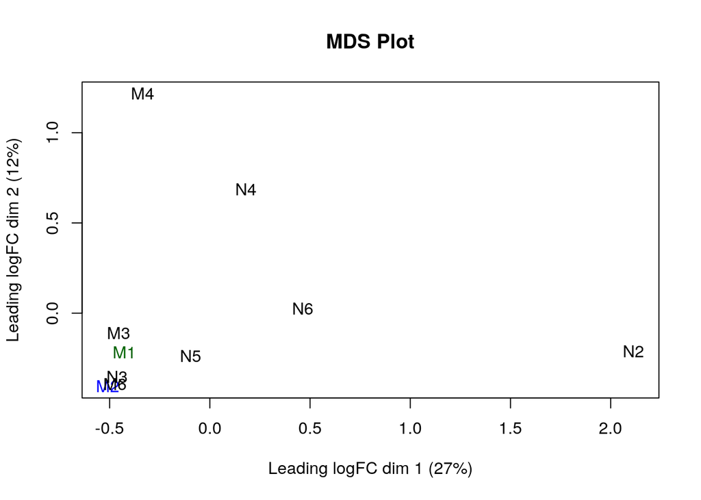

```r
plotMDS(d, labels=lapply(rownames(dataSamples), FUN=function(x){unlist(strsplit(x,split = "\\_"))[c(1)]}), col = c("darkgreen","blue")[factor(dataSamples$Status)], main="MDS Plot")
```

Samples are not cluster with each other, there are unpaired samples that show different expression. It seems that N3, M1, M2, M3 and M6 samples could be less different.

```r
model_design <- model.matrix(~dataSamples$Status)
```

```r
d <- estimateDisp(d, model_design)
```

Normalized Data Boxplot

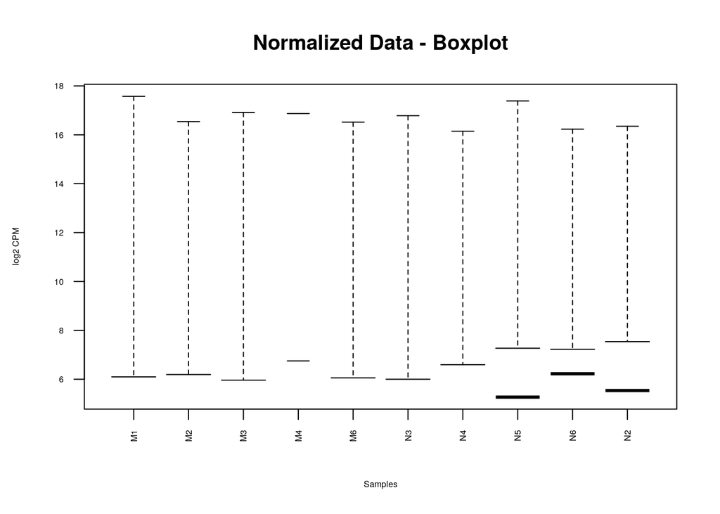

```r
data2plotNorm <- log2(normalized_counts)
colnames(data2plotNorm) <- lapply(colnames(d)[1:10],
                              FUN=function(x) {unlist(strsplit(x,
                              split="\\_"))[c(1)]})
boxplot(data2plotNorm, xlab = "Samples", ylab = "log2 CPM",
las = 2, cex = 0.5, cex.lab = 0.5,
cex.axis = 0.5, main = "Normalized Data - Boxplot")
abline(h = median(apply(data2plotNorm, 2, median)),
col = "darkgreen", lwd = 1.2, lty = "dashed")
```

I used normalized data to check boxplot, but I could not explain what that weird boxplot means.

Normalized Data Density plot

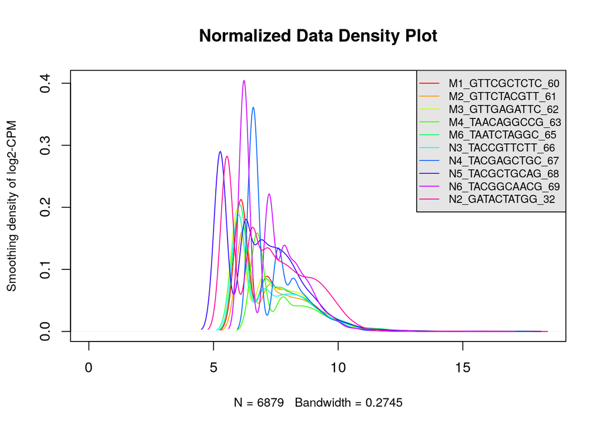

```r
norm_counts_density <- apply(log2(normalized_counts[,]),
2, density)
xlim <- 0; ylim <- 0
for (i in 1:length(norm_counts_density)) {
xlim <- range(c(xlim, norm_counts_density[[i]]$x));
ylim <- range(c(ylim, norm_counts_density[[i]]$y))
}
cols <- rainbow(length(norm_counts_density))
ltys <- rep(1, length(norm_counts_density))
plot(norm_counts_density[[1]], xlim=xlim, ylim=ylim, type="n",
ylab="Smoothing density of log2-CPM",
main="Normalized Data Density Plot", cex.lab = 0.85)
for (i in 1:length(norm_counts_density))
lines(norm_counts_density[[i]], col=cols[i], lty=ltys[i])
legend("topright", colnames(genes_expression[2:11]),
col=cols, lty=ltys, cex=0.75,
border ="blue", text.col = "black",
merge = TRUE, bg = "gray90")
```

Density plot of normalized does not add any information and I could not explain why.

**What are the control and test conditions of the dataset?** In this study, test condition includes 5 patients with metabolic syndrom, and controls include 5 healthy individuals.

**Why is the dataset of interest to you?** Metabolic syndrome is defined as a set of metabolic disturbances including but not limited to, obesity, hypertension, insulin resistance that eventually results in cardiovascular disorders, liver disease, and type 2 diabetes. Many people worldwide are suffering from this condition.<sup>20</sup>

**Were there expression values that could not be mapped to current HUGO symbols?** Yes. 24 genes are not mapped to the current HUGO symbols.

**How did you handle replicates?** Except for those with low counts, replicates in the control and test conditions have been used in the data.

All codes in this work are adapted from lectures instructed by Dr. Ruth Isserlin<sup>21</sup>

## References

1.

Xie Y, Allaire JJ, Grolemund G. *R Markdown: The Definitive Guide*. Chapman; Hall/CRC; 2018.

2.

Allaire J, Xie Y, McPherson J, et al. Rmarkdown: Dynamic documents for r. R package version 2.20.1. 2023.

3.

Xie Y, Dervieux C, Riederer E. *R Markdown Cookbook*. Chapman; Hall/CRC; 2020.

4.

Zhu H. *kableExtra: Construct Complex Table with ’Kable’ and Pipe Syntax*.; 2021. https://CRAN.R-project.org/package=kableExtra.

5.

Müller K, Wickham H, James DA, Falcon S. *RSQLite: SQLite Interface for r*.; 2023.

6.

R Special Interest Group on Databases (R-SIG-DB), Wickham H, Müller K. *DBI: R Database Interface*.; 2022.

7.

Davis S, Meltzer P. GEOquery: A bridge between the gene expression omnibus (GEO) and BioConductor. *Bioinformatics*. 2007;14:1846-1847.

8.

Morgan M. *BiocManager: Access the Bioconductor Project Package Repository*.; 2022. https://CRAN.R-project.org/package=BiocManager.

9.

Zhu Y, Davis S, Stephens R, Meltzer PS, Chen Y. GEOmetadb: Powerful alternative search engine for the gene expression omnibus. *Bioinformatics*. 2008;24(23):2798-2800.

10.

Durinck S, Spellman PT, Birney E, Huber W. Mapping identifiers for the integration of genomic datasets with the r/bioconductor package biomaRt. *Nature protocols*. 2009;4(8):1184-1191.

11.

Durinck S, Moreau Y, Kasprzyk A, et al. BioMart and bioconductor: A powerful link between biological databases and microarray data analysis. *Bioinformatics*. 2005;21(16):3439-3440.

12.

Drost H-G, Paszkowski J. Biomartr: Genomic data retrieval with r. *Bioinformatics*. 2017;33(8):1216-1217.

13.

Loraine AE, Blakley IC, Jagadeesan S, Harper J, Miller G, Firon N. Analysis and visualization of RNA-seq expression data using RStudio, bioconductor, and integrated genome browser. *Plant Functional Genomics: Methods and Protocols*. 2015:481-501.

14.

Robinson MD, McCarthy DJ, Smyth GK. edgeR: A bioconductor package for differential expression analysis of digital gene expression data. *bioinformatics*. 2010;26(1):139-140.

15.

Wickham H, Hester J, Chang W, Bryan J. *Devtools: Tools to Make Developing r Packages Easier*.; 2022.

16.

Dervieux C. *Pandoc: Manage and Run Universal Converter ’Pandoc’ from ’r’*.; 2022.

17.

Xie Y. *Knitr: A General-Purpose Package for Dynamic Report Generation in r*.; 2023. https://yihui.org/knitr/.

18.

Xie Y. *Dynamic Documents with R and Knitr*. 2nd ed. Boca Raton, Florida: Chapman; Hall/CRC; 2015. https://yihui.org/knitr/.

19.

Xie Y. Knitr: A comprehensive tool for reproducible research in R. In: Stodden V, Leisch F, Peng RD, eds. *Implementing Reproducible Computational Research*. Chapman; Hall/CRC; 2014.

20.

Li Y, Meng Y, Liu Y, Van Wijnen AJ, Eirin A, Lerman LO. Differentially expressed functional LncRNAs in human subjects with metabolic syndrome reflect a competing endogenous RNA network in circulating extracellular vesicles. *Frontiers in molecular biosciences*. 2021;8:667056.

21.

Isserlin R. BCB420, lectures 1 to 5. 2023.